# Curso 3 Limpieza y recolección de datos (Datawrangling)

## Raw data VS. Datos Procesados

El objetivo del curso es el siguiente:

- Raw data $\rightarrow$ script de procesamiento $\rightarrow$ tidy data $\rightarrow$ data analysis $\rightarrow$ data communication

Tidy data

- Cada variable que se mide debe estar en una columna
- Cada observación diferente debe estar en una sóla fila
- Debe haber una tabla por cada tipo de variable
- Si tenemos múltiples tablas, deben incluir una columna en la tabla que les permita enlazarlos.

Trucos:

- Incluir a fila al inicio con los nombres de las variables
- Hacer los nombres de las variables legibles
- En general, los datos deben ser salvados un archivo por cada tabla.

**CodeBook**

1. Información sobre las variables (unidades incluidas!!) del dataset no contenido en el tidy data
2. Información sobre las sumarizaciones que se han llevado a cabo
3. Información sobre el estudio experimental que se ha usado

Su formato habitual es word/text file. Debe haber una sección llamada “Diseño del estudio” que debe tener una información detallada de cómo se ha recolectado la información, y por último debe tener una sección llamada “Code Book” que describa cada variable y sus unidades.

**Instruction list**

idealmente es un script en R o en Python, el input del scrip es el raw data y la salida es el tidy data procesado. No debe tener parámetros.

En algunos casos no será posible hacer un script de con algunos de los pasos, en ese caso se debe proporcionar información del tipo:

```
Paso 1: Tomar el archivo de RawData y ejecutarlo con el software X
Paso 2: Coger la columna tres del archivo de salida y...
....
```

## Ficheros

Un primer caso habitual en la recogida de datos, será descargar de internet dicho fichero de datos. A continuación se describe el mejor proceso para hacerlo.

**Descarga de ficheros**

- **Establecer working directory**
  - *Relativo*: `setwd("./data")`, `setwd("../")` = move up in directory
  - *Absoluto*: `setwd("/User/Name/data")`
- **Comprobar si existe el fichero y descargarlo**
  - `if(!file.exists("./data")) {dir.create("./data")}`
- **Descarga**
  - `download.file(url, destfile= "directory/filname.extension", method = "curl")`
    - `method = "curl"` [mac only for https]
  - `dateDownloaded <- date()` = record the download date
- **Leer el fichero y cargar los datos**
  - `read.table()` = necesita especificar `file`, `header`, `sep`, `row.names`, `nrows`
    - `read.csv()` = automaticamente establece `sep = ","` and `header = TRUE`
  - `quote = ""` = no quotes (extremely helpful, common problem)
  - `na.strings` = establecer el carácter que representa NA
  - `nrows` = cuántas filas leer
  - `skip` = cuántas líneas saltar
  - `col.names` = especificar el nombre de las columnas
  - `check.names = TRUE/FALSE` = si está a TRUE, los nombres de las variables en el dataframe son chequeadas para asegurar que son nombres de variables sintácticamente válidos y no están duplicados, y si no es así intenta adecuarlo

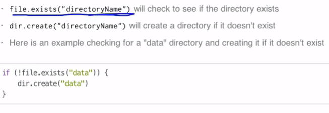

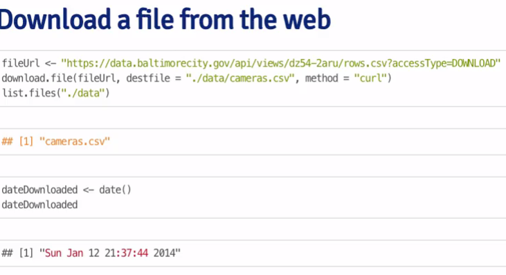

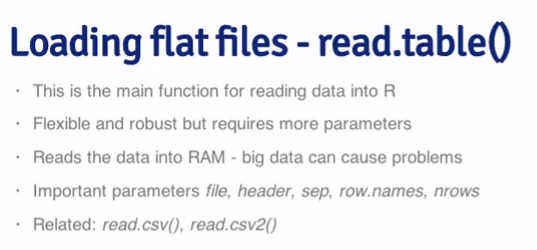

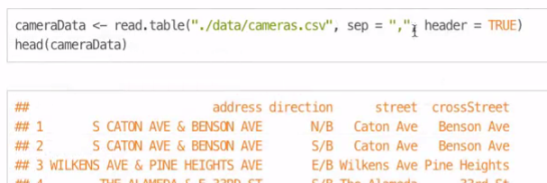

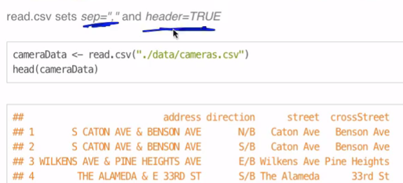

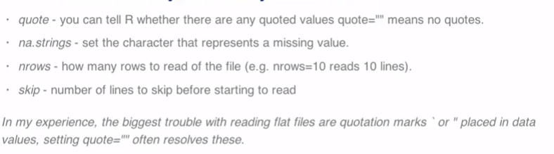

## Archivos Excel

- xlsx package: `read.xlsx(path, sheetIndex = 1, ...)`
  - `colIndex`, `rowIndex` = se usa para leer ciertas filas y columnas
- `write.xlsx()` = escribir el fichero a disco
- `read.xlsx2()` = más rápido que `read.xlsx()` pero instable para leer subconjuntos de filas
- `XLConnect` package más opciones para escribir/manipular archivos excel

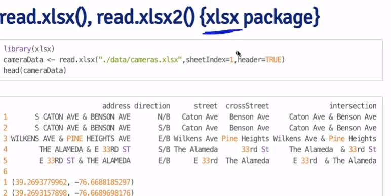

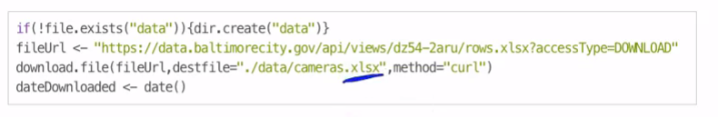

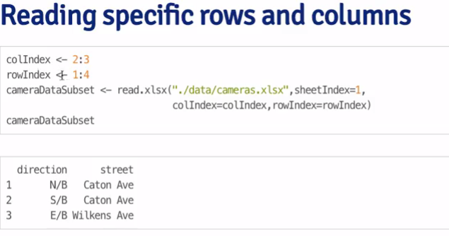

## Leer XML

- **XML** = extensible markup language
- frequented used to store structured data, widely used in Internet apps
- extracción de XML = base para la mayoría de webscrapping
- componentes
  - *markup* = etiquetas que dan la estructura
  - *contenido* = texto real del documento
- tags = `<section>`, `</section>`, `<line-break />`
- elements = `<Greeting>` test `</Greeting>`
- attributes = `<image src ="a.jpg" alt = "b">`
- leer archivo en R
  - `library(XML)`
  - `doc <- xmlTreeParse(fileUrl, useInternal = TRUE)` = loads data
  - `rootNode <- xmlRoot(doc)` = wrapper element for entire document
  - `xmlName(rootNode)` = returns name of the document
  - `names(rootNode)` = return names of elements
  - `rootNode[[1]]` = access first elements, similar to list
  - `rootNode[[1]][[1]]` = first sub component in the first element
  - `xmlSApply(rootNode, xmlValue)` = returns every single tagged element in the doc
- **XPath** ([new language](http://www.stat.berkeley.edu/~statcur/Workshop2/Presentations/XML.pdf))
  - get specific elements of document
  - `/node` = top level node
  - `//node` = node at any level
  - `node[@attr-name = 'bob']` = node with attribute name
    - `xpathSApply(rootNode, "//name", xmlValue)` = get the values of all elements with tag “name”
    - `xpathSApply(rootNode, "//price", xmlValue)` = get the values of all elements with tag “price”
- **extraer contenido por atributos**
  - `doc <- htmlTreeParse(url, useInternal = True)`
  - `scores <- xpathSApply(doc, "//li[@class='score']", xmlvalue)` = busca elementos li con `class = "score"` y devuelve su valor

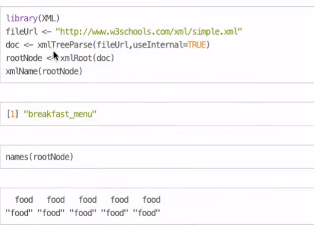

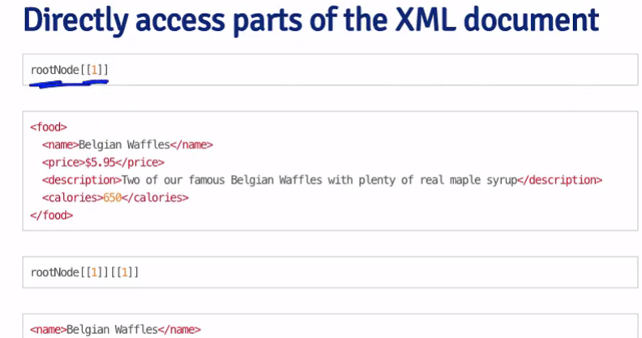

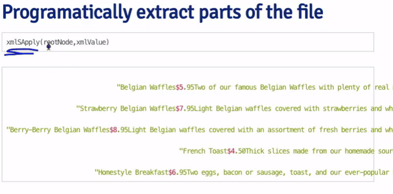

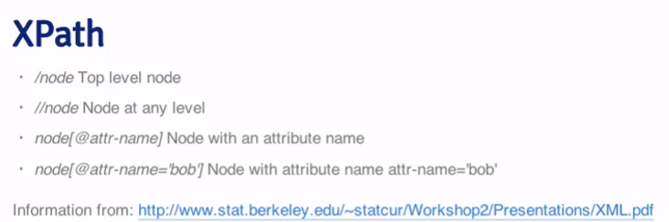

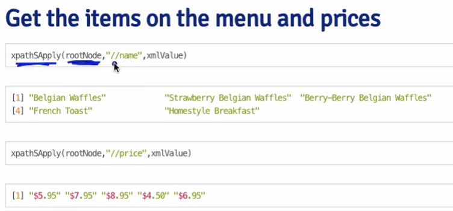

Otro ejemplo

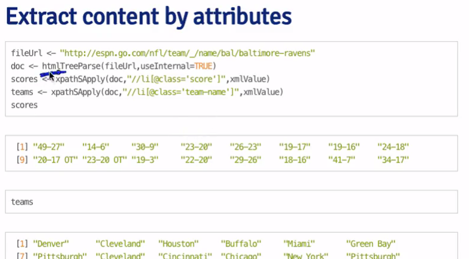

## Leer JSON

- **JSON** = JavaScript Object Notation
- almacenamiento ligero de datos, formato común para datos desde una API
- similar a XML en estructura pero diferente sintaxis
- los datos se pueden guardar como:
  - numbers (double)
  - strings (double quoted)
  - boolean (true/false)
  - array (ordered, comma separated enclosed in `[]`)
  - object (unordered, comma separated collection of key/value pairs enclosed in `{}`)
- `jsonlite` package (json vignette can be found in help)
  - `library(jsonlite)` = loads package
  - `data <- fromJSON(url)` = strips data
    - `names(data$owner)` = returns list of names of all columns of owner data frame
    - `data$owner$login` = returns login instances
  - `data <- toJSON(dataframe, pretty = TRUE)` = converts data frame into JSON format
    - `pretty = TRUE` = formats the code nicely
  - `cat(data)` = prints out JSON code from the converted data frame
  - `fromJSON()` = converts from JSON object/code back to data frame

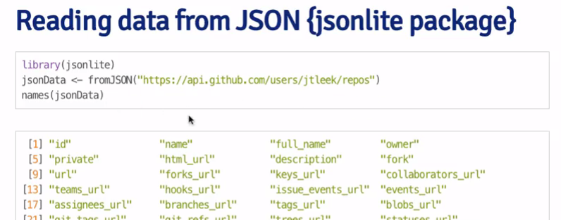

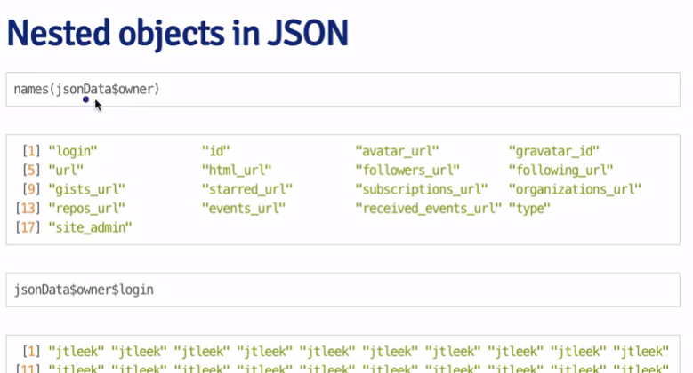

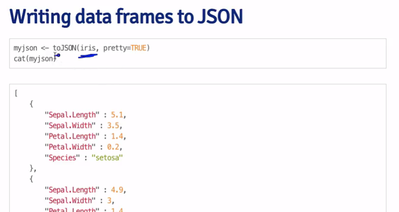

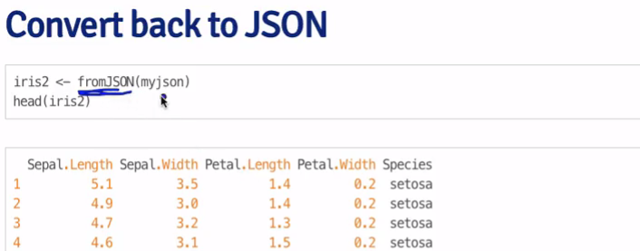

## DATA.TABLE

Es una versión más rápida y eficiente que los data.frames en algunas ocasiones.

- hereda de `data.frame` (external package) $\rightarrow$ todas las funciones que aceptan `data.frame` funcionan con `data.table`
- puede ser (escrito en C), *mucho mucho más rápido* agrupando,subsetting y actualizando
- **sintaxis**: `dt <- data.table(x = rnorm(9), y = rep(c("a","b","c"), each = 3), z = rnorm(9))`
- `tables()` = returns all data tables in memory
  - shows name, nrow, MB, cols, key
- some subset works like before = `dt[2, ], dt[dt$y=="a",]`
  - `dt[c(2, 3)]` = subset by rows, rows 2 and 3 in this case
- **Subconjuntos de colulmnas** (modified for `data.table`)
  - argument after comma is called an *expression* (collection of statements enclosed in `{}`)
  - `dt[, list(mean(x), sum(z))]` = returns mean of x column and sum of z column (no `""` needed to specify column names, x and z in ejemplo)
  - `dt[, table(y)]` = get table of y value (perform any functions)
- **añadir nuevas columnas**
  - `dt[, w:=z^2]`
    - when this is performed, a new data.table is created and data copied over (not good for large datasets)
  - `dt2 <- dt; dt[, y:= 2]`
    - when changes are made to dt, changes get translated to dt2
    - **Note**: if copy must be made, use the `copy()` function instead
- **operaciones múltiples**
  - `dt[, m:= {temp <- (x+z); log2(temp +5)}]` $\rightarrow$ adds a column that equals log2(x+z + 5)
- **plyr like operations**
  - `dt[,a:=x>0]` = creates a new column a that returns TRUE if x > 0, and FALSE other wise
  - `dt[,b:=mean(x+w), by=a]` = creates a new column b that calculates the aggregated mean for `x + w` for when a = TRUE/FALSE, meaning every b value is gonna be the same for TRUE, and others are for FALSE
- **variables especiales**
  - `.N` = returns integer, length 1, containing the number (essentially count)
    - `dt <- data.table (x=sample(letters[1:3], 1E5, TRUE))` = generates data table
    - `dt[, .N, by =x]` = crea una tabla para contar observaciones agrupadas en x
- **keys** (filtrar/subconjuntos rápidos)
  - *ejemplo*: `dt <- data.table(x = rep(c("a", "b", "c"), each = 100), y = rnorm(300))` = generates data table
    - `setkey(dt, x)` = establece la key en la columna x
    - `dt['a']` = devuelve un data frame, donde x = ‘a’ (effectively filter)
- **joins** (merging tables)
  - *ejemplo*: `dt1 <- data.table(x = c('a', 'b', ...), y = 1:4)` = generates data table
    - `dt2 <- data.table(x= c('a', 'd', ...), z = 5:7)` = generates data table
    - `setkey(dt1, x); setkey(dt2, x)` = sets the keys for both data tables to be column x
    - `merge(dt1, dt2)` = devuelve una tabla, combina las dos tablas usando la columna x filtrando sólo los valores que coinciden entre las dos columnas x y los junta
- **lectura rápida de ficheros**
  - *ejemplo*: `big_df <- data.frame(rnorm(1e6), rnorm(1e6))` = generates data table
    - `file <- tempfile()` = generates empty temp file
    - `write.table(big_df, file=file, row.names=FALSE, col.names = TRUE, sep = "\t", quote = FALSE)` = escribe los datos generados de big_df en tempfile
    - `fread(file)` = lee el archivo y carga los datos mucho más rápido que `read.table()`

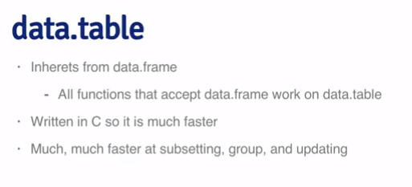

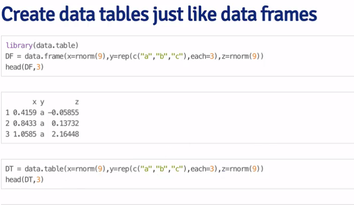

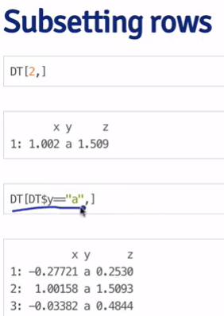

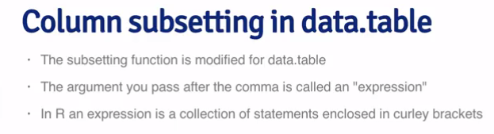